Facultad de Administración y Negocios Proyecto Analítica de Estudiantes

# Student Analytics UA — Informe metodológico

Fuentes, insumos, estadísticas descriptivas y metodología de la fase previa al acceso a datos institucionales

Autor/a

Proyecto Analítica de Estudiantes — Facultad de Administración y Negocios

Fecha de publicación

20 de octubre de 2026

**ImportanteNinguna cifra de este informe proviene de datos internos de la Universidad Autónoma**

Al momento de escribir este documento **el proyecto no tiene acceso a Banner ni a Canvas**. Todo lo que se reporta proviene de tres orígenes: datos abiertos del Ministerio de Educación de Chile, un conjunto de datos público del Reino Unido, y un generador sintético construido para este proyecto.

La única excepción son las cifras de retención de la propia Universidad Autónoma (§ Sección 7.1), que **sí son reales** pero provienen de las bases abiertas de Mineduc, no de sistemas internos.

# 1 Resumen ejecutivo

Este informe documenta la fase previa al acceso a los datos institucionales. Su propósito no fue construir un modelo, sino **dejar un pipeline cuyo contrato de entrada calce con Banner y Canvas lo bastante bien como para que la migración a datos reales sea un cambio de configuración**, y producir la evidencia que justifica solicitar ese acceso.

Los tres resultados principales:

1. **La retención real de la Universidad Autónoma se puede calcular hoy**, desde datos abiertos, cruzando las bases de matrícula por el identificador MRUN. En el área de Administración y Comercio la cohorte 2024 retuvo **84,1%** en la misma carrera. Entre sedes hay una brecha de **14 puntos**.
2. **Todo el expediente escolar previo predice poco.** Con 135.050 ingresantes universitarios y validación temporal, un modelo con NEM, ranking, notas de enseñanza media, los cinco puntajes PAES, dependencia del colegio, **asistencia mensual de 4° medio, decil de ingreso oficial, condición de prioritario y tipo de financiamiento** alcanza **AUC 0,636**. Solo la ficha de admisión llega a 0,617; todo el resto suma 0,019.
3. **Los datos de comportamiento superan a ese expediente antes del primer mes.** Sobre datos reales de la Open University, un baseline conductual alcanza **AUC 0,697 en la semana 4** — con el 10% del curso transcurrido y sin registro de asistencia.

De ahí se sigue el argumento del proyecto: el valor no está en lo que ya se sabe del estudiante al matricularse, sino en lo que ocurre durante el semestre.

# 2 Mandato y alcance

## 2.1 Insumos documentales

El proyecto se apoya en tres documentos, incluidos en `docs/`:

| Documento | Origen | Qué aporta |
| --- | --- | --- |
| *2026 Postulación FPDA BA v3* | Formulario Fondo de Desarrollo Académico, Universidad Autónoma de Chile | El mandato formal: alcance, compromisos e indicadores por mes |
| *AT_informe-final-2* | Hofflinger, A. (2020). Universidad de Los Lagos | Benchmark metodológico; el hallazgo que define el problema |
| *Actualiza-Titulos-Grados* | Subsecretaría de Educación Superior | Marco sistémico: masificación, heterogeneidad, trayectorias flexibles |

## 2.2 Compromisos formales

La postulación adjudicada compromete plazos concretos:

| Compromiso | Plazo |
| --- | --- |
| Permisos de acceso a los datos consolidados por la VRA | antes del mes 2 |
| Segmentos de estudiantes obtenidos | antes del mes 3 |
| ≥3 algoritmos entrenados, modelo priorizado 1 | antes del mes 4 |
| ≥3 algoritmos entrenados, modelo priorizado 2 | antes del mes 6 |

Quedan explícitamente **fuera de alcance** las acciones preventivas de las direcciones de carrera y cualquier implementación dentro de Banner.

## 2.3 El hallazgo que define el problema

El informe de la Universidad de Los Lagos es el antecedente más relevante. Su resultado central:

> Con solo datos previos al ingreso (género, etnia, NEM, PSU, ingreso familiar, dependencia), para alcanzar al 80% de los futuros desertores había que intervenir al **80% de los estudiantes**. Incorporando las notas del primer semestre, capturar el 60% requería solo el **20%**.

Y su recomendación explícita fue mejorar la predicción durante el primer semestre incorporando **notas parciales, asistencia y uso de plataformas virtuales**. Este proyecto es la continuación operativa de esa recomendación.

# 3 Hallazgos principales

Esta sección reúne lo que el proyecto encontró. Cada cifra sale de `documentacion/datos/hallazgo_*.csv`, que genera `scripts/build_findings.py` desde los mismos artefactos que alimentan el tablero: **ninguna está escrita a mano**, y la sección «Hallazgos» de la aplicación muestra exactamente estos mismos números. Las secciones posteriores desarrollan cada punto.

## 3.1 1. El valor no está en lo que ya se sabe del estudiante

Figura 1: Poder predictivo del expediente previo al ingreso frente al comportamiento observado en la semana 4

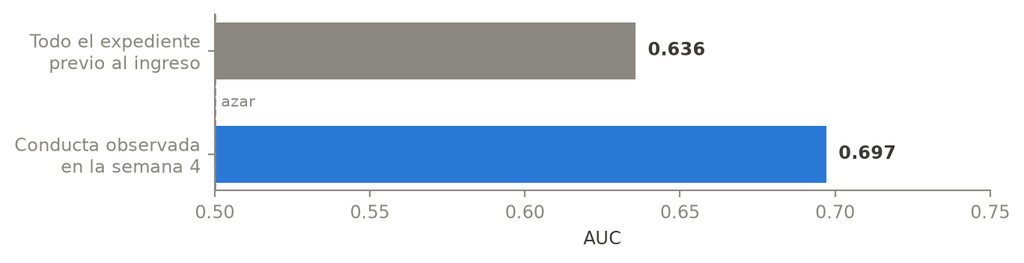

Tabla 1: Los dos resultados, uno junto al otro

|  | Momento | Qué se sabe | n | AUC | Margen para actuar |
| --- | --- | --- | --- | --- | --- |
| 0 | Antes de entrar a la universidad | Expediente completo: PAES, NEM, ranking, coleg... | 135,050 | 0.636 | Antes del primer día de clases |
| 1 | Semana 4 del curso | Solo comportamiento observado en la plataforma... | 13,144 | 0.697 | Quedan 35 semanas para actuar |

Todo lo que el Estado de Chile sabe de un estudiante **antes de que pise la universidad** —NEM, ranking, pruebas de admisión, dependencia del colegio, asistencia mensual de cuarto medio, decil de ingreso oficial, condición de prioritario, tipo de financiamiento— se queda por debajo de un modelo que solo mira **cuatro semanas de comportamiento** dentro del curso, y que ni siquiera dispone de asistencia.

**ImportanteLa consecuencia operativa**

Un sistema de alerta temprana construido sobre la ficha de admisión ordena poco mejor que el azar y, sobre todo, **no cambia durante el semestre**: clasifica al estudiante el día que se matricula y lo deja ahí. El comportamiento observado sí se mueve, y por eso admite una intervención.

Ese es el caso para pedir acceso a Banner y Canvas. Detalle en Sección 8.

## 3.2 2. La UA está sobre el sistema en continuidad, y la brecha entre sedes es interna

Figura 2: Continuidad en la misma universidad al año siguiente: UA frente al resto del sistema, 19 cohortes

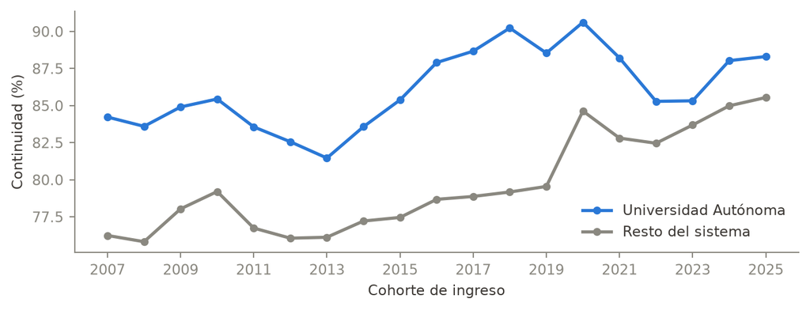

La UA supera al resto del sistema en **todas** las cohortes de la serie. La referencia excluye a la UA, de modo que una institución grande no atenúe su propia comparación.

Tabla 2: Continuidad por sede — área del piloto, última cohorte disponible

|  | Sede | n | Misma carrera | Misma universidad | Cualquier institución |
| --- | --- | --- | --- | --- | --- |
| 0 | CASA CENTRAL (TEMUCO) | 201 | 85.6% | 89.6% | 95.0% |
| 1 | CAMPUS PROVIDENCIA | 270 | 85.6% | 87.0% | 92.6% |
| 2 | CAMPUS EL LLANO | 98 | 79.6% | 81.6% | 90.8% |
| 3 | SEDE TALCA | 150 | 78.7% | 86.0% | 91.3% |

**TipLa sede debe ser variable del modelo, no filtro del tablero**

En la cohorte 2025 la distancia entre la sede con mayor y menor continuidad es de **6.9 puntos porcentuales**, con la sede más pequeña aportando 98 inscripciones. En la cohorte 2024, que es la que se analiza en detalle en Sección 7.1, esa brecha llegó a 14 puntos.

El rango se mueve de un año a otro, pero el punto no depende de su magnitud exacta: una institución que está **sobre** el promedio nacional contiene internamente una dispersión que el promedio esconde. Es el tipo de heterogeneidad que un modelo debe capturar y un indicador agregado no.

## 3.3 3. La UA es del montón en selectividad, y no se mueve

Tabla 3: Posición de la UA en selectividad de admisión, por cohorte

|  | Cohorte | Prueba | Puntaje UA | Media del sistema | Percentil UA | Supera a | Universidades | Cobertura UA |
| --- | --- | --- | --- | --- | --- | --- | --- | --- |
| 0 | 2021 | PDT | 524 | 533 | 58% | 48% | 50 | 84% |
| 1 | 2022 | PDT | 516 | 534 | 54% | 39% | 51 | 88% |
| 2 | 2023 | PAES | 610 | 620 | 55% | 51% | 51 | 87% |
| 3 | 2024 | PAES | 624 | 635 | 56% | 50% | 50 | 88% |
| 4 | 2025 | PAES | 627 | 639 | 54% | 51% | 49 | 88% |

La UA **no recibe estudiantes mejores ni peores que el promedio** del sistema, y esa posición es estable en las cinco cohortes con dato. El hallazgo importa porque cierra una explicación fácil: sus resultados de continuidad y titulación no se explican por el perfil de entrada.

**AdvertenciaDos advertencias que la cifra no lleva encima**

**El puntaje crudo no cruza 2023.** La Prueba de Transición se medía entre 150 y 850 y la PAES entre 100 y 1000, así que la columna «Puntaje UA» salta unos noventa puntos entre 2022 y 2023 sin que haya cambiado nada. El percentil nacional sí es comparable, y es la columna que debe leerse en serie. Ver Sección 5.2.1.

**Antes de 2021 no hay dato.** La PSU no está publicada como microdato abierto, así que catorce de las diecinueve cohortes del benchmark se comparan sin selectividad.

## 3.4 4. Los dos indicadores de titulación apuntan en direcciones opuestas

Figura 3: Correlación de cada indicador de titulación con la selectividad de admisión y con los años de acreditación

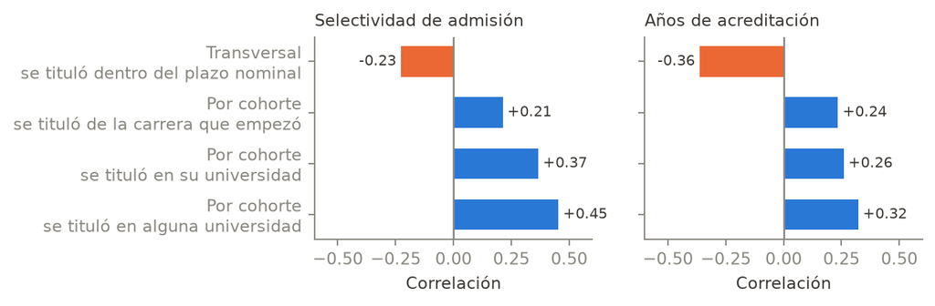

Sobre **las mismas universidades**, la titulación transversal correlaciona en sentido contrario a la titulación por cohorte. No es ruido: miden cosas distintas.

- **La transversal mide velocidad, no logro.** Cuenta cuánto se demoró quien *sí* se tituló, y eso lo determina la mezcla de carreras: una universidad con mucha ingeniería aparece abajo porque esos programas se alargan, no porque enseñe peor. Por eso correlaciona **negativo** con selectividad y con acreditación.
- **La de cohorte mide cuántos llegan.** Toma a quienes entraron y los busca en las bases de titulados por MRUN. Correlaciona **positivo** con ambas referencias, que es como debe comportarse un indicador de resultado.

**ImportanteConsecuencia para el uso institucional**

La titulación oportuna dejaba a la UA en el percentil 94 del sistema. **Ese número no debe presentarse como logro**: es en buena parte composición de oferta. El indicador por cohorte —donde la UA marca 61,4% frente a una mediana de 51,2%— es el que sostiene una afirmación sobre desempeño. Ver Sección 7.2.

## 3.5 5. Cuatro modelos entrenados, un solo veredicto favorable

Desde octubre de 2026 el proyecto tiene modelos entrenados sobre estudiantes de la UA, no sobre datos sintéticos. Dos usan datos abiertos cruzados por MRUN y dos usan el **extracto institucional 2024–2025** que entregó la universidad.

Tabla 4: Modelos del piloto FAN: métricas del test reservado y veredicto

|  | Caso | Qué predice | Estado | Algoritmo | AUC | Captura 20% | Regla histórica | n test | Eventos |
| --- | --- | --- | --- | --- | --- | --- | --- | --- | --- |
| 0 | continuidad | No continuidad al año siguiente | señal retrospectiva | Random forest | 0.683 | 43.6% | 22.0% | 714 | 94 |
| 1 | titulacion | No titulación en el horizonte | experimental | Gradient boosting | 0.583 | 27.7% | 21.4% | 517 | 84 |
| 2 | academico | Resultado académico del semestre siguiente | experimental | Regresión logística | 0.812 | 43.1% | — | 1,972 | 678 |
| 3 | matricula | No presencia en matrícula del semestre siguiente | experimental | Random forest | 0.888 | 75.0% | — | 2,318 | 16 |

**ImportanteEl veredicto no es la métrica**

Un modelo pasa a **señal retrospectiva** solo si supera a la regla histórica por carrera, al azar en captura, **y** mejora el Brier frente a una probabilidad constante aprendida en entrenamiento. Si falla cualquiera de las tres, queda **experimental**.

**Ninguno autoriza uso individual.** Son reconstrucciones retrospectivas de registros académicos, no un servicio que hubiera existido en esas fechas.

El único con veredicto favorable es **continuidad**: AUC 0,683 y captura del 43,6% al revisar el 20%, frente al 22,0% de priorizar por la tasa histórica de la carrera. Casi el doble, que es la comparación que importa para una dirección que ya podría usar esa heurística sin ningún modelo.

### 3.5.1 Lo que el extracto institucional cambió

Pero el orden de magnitud confirma la tesis del informe. Con el expediente nacional previo al ingreso el techo medido fue 0,636 (Sección 8); agregando estructura institucional —carrera, sede, jornada— el modelo de continuidad llega a 0,683; agregando **notas del semestre**, el académico llega a 0,812.

> El valor no está en lo que se sabe del estudiante al matricularse, sino en lo que ocurre durante el semestre. Eso dejó de ser un argumento prestado de ULagos y pasó a ser una medición sobre estudiantes de la UA.

**AdvertenciaLo que el extracto no acredita**

Recibir el archivo no equivale a tener acceso a los sistemas. No hay permisos formales de la VRA, no hay Canvas, no hay conexión automática, y la fecha de corte del extracto **no fue informada**. Mientras esa pregunta siga abierta, la ausencia de una persona en el archivo no se lee como deserción y los registros no se presentan como alumnos activos actuales.

## 3.6 6. Las trampas de datos que cambiaron un resultado

Esta es la parte del trabajo que no aparece en ningún gráfico y es la que sostiene todo lo demás. Cada fila es un error que los datos inducen con toda naturalidad y que habría producido una conclusión falsa.

Tabla 5: Trampas encontradas, con el efecto medido de no corregirlas

|  | Fuente | Qué trae el dato | Qué pasa si no se corrige | Estado |
| --- | --- | --- | --- | --- |
| 0 | PAES / PDT | El valor 0 significa «no rindió», no «obtuvo c... | Tratarlo como puntaje hunde todas las medias i... | Corregido |
| 1 | PAES / PDT | Cambio de escala en 2023 (150–850 → 100–1000) | El promedio institucional salta ~90 puntos ent... | Corregido con percentil nacional |
| 2 | Admisión | La PSU (2004–2020) no está publicada | 14 de 19 cohortes no pueden medir selectividad | Límite permanente |
| 3 | Matrícula | Falta cod_carrera en 24,5% de la cohorte 2007 ... | La continuidad de carrera aparece en 53,9% en ... | Detectado y advertido |
| 4 | Matrícula | anio_ing_carr_ori usa 9999 y 9995 como centinela | Cohortes contaminadas con años imposibles | Corregido |
| 5 | Titulados | anio_ing_carr_ori usa 1900 como centinela, en ... | La duración media pasa de 5 a 17,4 años, con m... | Corregido |
| 6 | Titulados | Los planes de continuidad reconocen estudios p... | Sobreduración 3,52 años contra 0,58 del plan r... | Corregido |
| 7 | Titulados | La duración nominal viene en SEMESTRES | Sin dividir por dos, toda sobreduración sale n... | Corregido |
| 8 | Longitudinal | La censura por derecha también sesga por insti... | La UA aparecía primera del sistema en 2018 con... | Corregido con piso de cobertura |
| 9 | Longitudinal | Filtrar por año después de agregar por clave | Un título previo anulaba al estudiante entero;... | Corregido |
| 10 | Matrícula | valor_arancel mezcla pesos y UF en la misma co... | 7.638 filas en UF (mediana 215) junto a 145.86... | Corregido |
| 11 | Becas | La base de asignaciones no contiene el CAE | La variable salía constante en cero; la admini... | Reemplazado por FSCU y beca de arancel |
| 12 | CNED | «Tradicional» marca pertenencia al CRUCH, no a... | Desde la Ley 21.091 el CRUCH admite privadas; ... | Corregido |
| 13 | Clustering | La silueta elige siempre la partición que aísl... | k=2 dejaba al 92% de las universidades —la UA ... | Corregido con techo de concentración |

«Límite permanente» significa que no hay corrección posible con datos abiertos: es una restricción de la fuente, no del pipeline.

## 3.7 7. Qué aportó cada fuente

Tabla 6: Cobertura y aporte de cada fuente al perfil institucional

|  | Fuente | Grano | Cobertura | Qué aporta | Variables en el perfil |
| --- | --- | --- | --- | --- | --- |
| 0 | Matrícula en Educación Superior (SIES) | Individual (MRUN) | 2007–2026 | Cohortes de ingreso, continuidad, perfil de of... | 38 |
| 1 | Titulados en Educación Superior | Individual (MRUN) | 2007–2025 | Titulación transversal y por cohorte | 13 |
| 2 | Pruebas de admisión (PDT y PAES) | Individual (MRUN) | 2021–2026 | Selectividad de admisión | 9 |
| 3 | CNED INDICES institucional | Institución × año | 2005–2025 | Cuerpo docente, infraestructura, acreditación | 16 |
| 4 | Asistencia escolar, SEP y becas | Individual (MRUN) | 2022–2024 | Piso predictivo previo al ingreso | 0 |
| 5 | OULAD (Open University) | Estudiante × módulo × semana | 28.785 estudiantes | Validar la anticipación con conducta real | 0 |

El conteo de variables se deriva del perfil generado, no de una lista escrita a mano: si se incorpora una fuente nueva, la cifra se mueve sola.

# 4 Fuentes de datos

## 4.1 Fuentes utilizadas

| Fuente | Grano | Licencia | Rol en el proyecto |
| --- | --- | --- | --- |
| [Matrícula en Educación Superior](https://datosabiertos.mineduc.cl/matricula-en-educacion-superior/) 2007–2026 | Individual (MRUN) | Datos abiertos de gobierno | Retención real UA; población de los modelos; cohortes de ingreso del seguimiento longitudinal |
| [Titulados en Educación Superior](https://datosabiertos.mineduc.cl/titulados-en-educacion-superior/) 2007–2025 | Individual (MRUN) | Datos abiertos de gobierno | Titulación de la promoción que egresa y titulación por cohorte de ingreso |
| [Pruebas de admisión (PDT y PAES)](https://datosabiertos.mineduc.cl/pruebas-de-admision-a-la-educacion-superior/) 2021–2026 | Individual (MRUN) | Datos abiertos de gobierno | Variables previas al ingreso; selectividad de admisión |
| [Asistencia anual por estudiante](https://datosabiertos.mineduc.cl/asistencia-anual-por-estudiante/) 2022, 2023 | Individual (MRUN + RBD), tasa mensual | Datos abiertos de gobierno | Asistencia de enseñanza media y su pendiente |
| [Alumnos SEP](https://datosabiertos.mineduc.cl/alumnos-preferentes-prioritarios-y-beneficiarios-sep/) 2022, 2023 | Individual (MRUN + RBD) | Datos abiertos de gobierno | Vulnerabilidad individual: prioritario / preferente |
| [Asignaciones de Becas y Créditos](https://datosabiertos.mineduc.cl/asignaciones-de-becas-y-creditos-en-educacion-superior/) 2023, 2024 | Individual (MRUN) | Datos abiertos de gobierno | Quintil, decil DFE, gratuidad, FSCU, beca de arancel |
| [OULAD](https://analyse.kmi.open.ac.uk/open_dataset) | Estudiante × módulo × semana | CC-BY 4.0 | Validar la metodología con datos reales de comportamiento |
| [Canvas Data 2 — esquema](https://developerdocs.instructure.com/services/dap/dataset) | Documentación | Pública | Nombres reales de tablas y columnas |
| [Banner ODS Handbook](https://tech.wayne.edu/depdocs/banner-ods-handbook-8-4.pdf) | Documentación | Publicada por Wayne State University | Nombres reales de tablas Banner |
| Generador sintético | Estudiante × asignatura × semana | Propio | Forma UA completa: sedes, carreras, asistencia, escala 1,0–7,0 |

**Cita de OULAD:** Kuzilek, J., Hlosta, M., & Zdrahal, Z. (2017). Open University Learning Analytics dataset. *Scientific Data*, 4, 170171.

## 4.2 Sobre el identificador MRUN

Las bases de Mineduc están desagregadas **a nivel individual** y usan MRUN, un identificador ficticio pero **estable entre bases y años**, que permite seguir la trayectoria de una persona desde prekínder hasta doctorado. Chile es de los pocos países OCDE que publica esto abiertamente.

**AdvertenciaMRUN no se puede unir a Banner**

MRUN es un RUT enmascarado y no existe tabla de equivalencia pública. **Estas bases no pueden generar features de estudiantes concretos de la UA.** Sirven para calibrar, para benchmarking y para argumentar — no para modelar individuos.

## 4.3 Fuentes identificadas y no utilizadas todavía

Unibles a estudiantes de la UA por claves **no personales** (RBD del colegio de origen, comuna), y por tanto candidatas legítimas a features:

| Fuente | Llave | Feature potencial |
| --- | --- | --- |
| [JUNAEB — IVE](http://junaebabierta.junaeb.cl/catalogo-de-datos/indicadores-de-vulnerabilidad/) | RBD | Índice de vulnerabilidad del colegio (0–100) |
| Agencia de Calidad — SIMCE | RBD | Rendimiento histórico del establecimiento |
| [Rendimiento por estudiante](https://datosabiertos.mineduc.cl/rendimiento-por-estudiante-2/) | MRUN + RBD | Notas y promoción año a año en enseñanza media |
| [Matrícula longitudinal](https://datosabiertos.mineduc.cl/matricula-longitudinal/) | MRUN | Trayectoria escolar ya encadenada por el Mineduc |
| [Notas de enseñanza media y percentil](https://datosabiertos.mineduc.cl/notas-de-ensenanza-media-y-percentil-jovenes/) | MRUN | NEM y percentil de egreso; podría cubrir cohortes anteriores a 2021 |
| [Postulaciones a Becas y Créditos](https://datosabiertos.mineduc.cl/postulaciones-a-becas-y-creditos-en-educacion-superior/) | MRUN | Datos FUAS: composición del hogar, ingresos declarados |
| Matrícula ES (calculado) | RBD | Persistencia en educación superior de los egresados de ese colegio |
| CASEN | comuna | Contexto socioeconómico |

El catálogo completo de `datosabiertos.mineduc.cl` tiene **48 conjuntos de datos**. La prioridad de incorporación debería guiarse por el resultado de la ablación (§ Sección 7): las variables previas al ingreso ya mostraron rendimientos decrecientes, así que conviene invertir el esfuerzo en los datos institucionales antes que en más fuentes públicas.

Ver § Sección 9 para la razón por la que su incorporación requiere cuidado.

## 4.4 Fuentes de contexto (solo agregadas)

[CNED INDICES](https://www.cned.cl/indices), informes SIES, [mifuturo.cl](https://www.mifuturo.cl/bases-de-datos/), [datos.gob.cl](https://datos.gob.cl/group/educacion). Útiles para benchmarking y acreditación; no aportan al modelamiento.

# 5 Estadísticas descriptivas por fuente

Una subsección por fuente, con su grano, su cobertura y las variables que el proyecto efectivamente usa. Todas las cifras provienen de `documentacion/datos/`, que `scripts/descriptive_stats.py` regenera desde las bases originales.

## 5.1 Matrícula en Educación Superior (Mineduc / SIES)

Tabla 7: Volumen de las bases de matrícula en educación superior

|  | Año | Filas |
| --- | --- | --- |
| 0 | 2023 | 1,341,446 |
| 1 | 2024 | 1,386,084 |
| 2 | 2025 | 1,454,252 |

De la base 2024 (1,386,084 filas), la Universidad Autónoma registra **29,889 matriculados de pregrado**, de los cuales **6,475 son cohorte de ingreso 2024**.

Sedes identificadas: CAMPUS EL LLANO, CAMPUS PROVIDENCIA, CASA CENTRAL (TEMUCO), SEDE TALCA.

Tabla 8: Matriculados 2024 de la UA en el área Administración y Comercio

|  | Carrera | Matriculados 2024 |
| --- | --- | --- |
| 0 | INGENIERIA COMERCIAL | 2186 |
| 1 | AUDITORIA E INGENIERIA EN CONTROL DE GESTION | 584 |
| 2 | INGENIERIA EN ADMINISTRACION | 258 |
| 3 | INGENIERIA EN CONTROL DE GESTION | 213 |

## 5.2 Pruebas de admisión PAES (Mineduc / DEMRE)

**Grano:** una fila por inscrito, con `MRUN` y `RBD` del establecimiento de egreso. 130 columnas. Proceso de admisión 2024.

En esta base **el valor 0 significa “no rindió esa prueba”, no “obtuvo cero”**. Tratarlo como puntaje desplaza todas las medias hacia abajo y arruina cualquier modelo; en el pipeline se convierte explícitamente a valor ausente.

Tabla 9: Puntajes y expediente escolar — PAES 2024 (excluyendo a quienes no rindieron)

|  | Variable | % que rindió | Media | DE | p25 | p50 | p75 |
| --- | --- | --- | --- | --- | --- | --- | --- |
| 0 | Promedio de notas de ensenanza media | 98.3% | 6.0 | 0.5 | 5.5 | 6.0 | 6.3 |
| 1 | Puntaje NEM | 98.3% | 698.8 | 151.6 | 587.0 | 700.0 | 816.0 |
| 2 | Puntaje ranking | 98.3% | 716.0 | 165.0 | 592.0 | 718.0 | 849.0 |
| 3 | PAES Competencia Lectora | 88.4% | 613.9 | 132.8 | 510.0 | 607.0 | 707.0 |
| 4 | PAES Matematica M1 | 87.4% | 603.7 | 140.9 | 505.0 | 576.0 | 679.0 |
| 5 | PAES Matematica M2 | 42.7% | 419.9 | 111.8 | 348.0 | 395.0 | 459.0 |
| 6 | PAES Historia y Cs. Sociales | 49.3% | 501.3 | 128.2 | 402.0 | 484.0 | 587.0 |
| 7 | PAES Ciencias | 61.9% | 494.5 | 107.8 | 418.0 | 478.0 | 546.0 |

La cobertura es informativa por sí misma: casi todos rinden Competencia Lectora y Matemática M1, pero **solo el 43% rinde Matemática M2** y la mitad rinde Historia. Un modelo que use M2 como predictor lo estará imputando para más de la mitad de los casos.

Tabla 10: Dependencia del establecimiento de egreso

|  | Dependencia | n | Proporción |
| --- | --- | --- | --- |
| 0 | Particular Subvencionado | 164257 | 53.1% |
| 1 | Municipal | 55629 | 18.0% |
| 2 | Particular Pagado | 32448 | 10.5% |
| 3 | Corporacion Municipal | 28545 | 9.2% |
| 4 | Servicio Local de Educacion | 13084 | 4.2% |
| 5 | Corp. de Administracion Delegada | 10455 | 3.4% |
| 6 | NaN | 4932 | 1.6% |

### 5.2.1 Qué años hay, y el corte de escala de 2023

El portal publica los puntajes **desde 2021**, con tres nombres distintos para la misma base según el año: *Prueba de Transición Universitaria* (2021–2022), *Prueba de Acceso a la Educación Superior* (2023) y *PAES* (2024 en adelante). Por eso el descargador lee el catálogo de la página y reconoce por patrón, en vez de fijar rutas.

Tabla 11: Instrumento, escala y cobertura por año de admisión

|  | Año de admisión | Prueba | Inscritos | Rindieron | Cobertura | Mínimo | Media | Máximo |
| --- | --- | --- | --- | --- | --- | --- | --- | --- |
| 0 | 2021 | PDT | 276,059 | 226,610 | 82.1% | 150 | 502 | 844 |
| 1 | 2022 | PDT | 285,513 | 244,579 | 85.7% | 150 | 506 | 842 |
| 2 | 2023 | PAES | 296,812 | 258,757 | 87.2% | 148 | 599 | 1,000 |
| 3 | 2024 | PAES | 309,350 | 268,915 | 86.9% | 100 | 610 | 995 |
| 4 | 2025 | PAES | 313,759 | 270,604 | 86.2% | 100 | 617 | 1,000 |
| 5 | 2026 | PAES | 320,087 | 271,376 | 84.8% | 100 | 628 | 1,000 |

**ImportanteLos puntajes no son comparables entre 2022 y 2023**

La PDT se medía entre **150 y 850** con media 500; la PAES pasó a **100 y 1000** con media cercana a 610, y además separó Matemática M1 de M2. Un promedio institucional salta unos cien puntos entre ambas cohortes sin que haya cambiado nada real. Cualquier serie que cruce ese corte con el puntaje crudo está inventando una tendencia.

El pipeline lo resuelve de dos maneras. Reconstruye para la PDT el mismo promedio que la PAES trae calculado —se verificó que `PROMEDIO_CM_MAX` es exactamente la media de Competencia Lectora y Matemática, tomando el mejor puntaje entre el año y el anterior— y expone además `paes_percentil_promedio`, el percentil nacional dentro de cada cohorte. El percentil **sí** cruza el corte: quedar sobre el 70% del país significa lo mismo con cualquiera de las dos pruebas.

Para el agrupamiento de pares el corte es inocuo, porque cada cohorte se estandariza y se agrupa por separado.

**AdvertenciaLa PSU no está en datos abiertos**

La serie **no puede extenderse antes de 2021**. La PSU (2004–2020) no aparece en la página de admisión ni en ninguna de las 48 secciones del portal del Mineduc; quien la necesite debe pedirla al DEMRE por su proceso de acceso a datos de investigación.

## 5.3 Trayectoria escolar previa al ingreso

Tres bases adicionales de Mineduc, unidas por `MRUN` al año anterior al ingreso de cada cohorte:

| Base | Grano | Variables usadas |
| --- | --- | --- |
| Asistencia anual por estudiante | MRUN + RBD, **tasa mensual marzo–diciembre** | Asistencia anual, pendiente, mínimo, último trimestre |
| Alumnos SEP | MRUN + RBD | Prioritario, preferente |
| Asignaciones de Becas y Créditos | MRUN | Quintil, decil DFE, gratuidad, FSCU, beca de arancel |

La variable más interesante no es el nivel de asistencia sino su **pendiente**: un estudiante que baja de 95% en marzo a 70% en noviembre de 4° medio ya se estaba desenganchando antes de matricularse. Es el mismo fenómeno que el proyecto busca detectar dentro del semestre.

Tabla 12: Trayectoria escolar — cohorte de ingreso 2024

|  | Variable | Cobertura | Media | DE | p25 | p50 | p75 |
| --- | --- | --- | --- | --- | --- | --- | --- |
| 0 | asis_em_anual | 54.6% | 0.8807 | 0.1131 | 0.8435 | 0.9091 | 0.9548 |
| 1 | asis_em_pendiente | 54.6% | -0.0092 | 0.0274 | -0.0166 | -0.0026 | 0.0041 |
| 2 | asis_em_min | 54.6% | 0.6315 | 0.2849 | 0.5238 | 0.7143 | 0.8421 |
| 3 | asis_em_ultimo_trimestre | 54.6% | 0.8541 | 0.1952 | 0.8036 | 0.9286 | 1.0000 |
| 4 | quintil_ingreso | 70.4% | 2.2641 | 0.7019 | 2.0000 | 2.0000 | 3.0000 |
| 5 | decil_dfe | 70.4% | 4.2747 | 1.2974 | 4.0000 | 4.0000 | 5.0000 |
| 6 | prioritario | 100.0% | 0.3852 | NaN | NaN | NaN | NaN |
| 7 | preferente | 100.0% | 0.2291 | NaN | NaN | NaN | NaN |
| 8 | gratuidad | 100.0% | 0.6190 | NaN | NaN | NaN | NaN |
| 9 | fscu | 100.0% | 0.0115 | NaN | NaN | NaN | NaN |
| 10 | beca_arancel | 100.0% | 0.1143 | NaN | NaN | NaN | NaN |

**AdvertenciaEl CAE no está en estas bases**

La base de Asignaciones cubre gratuidad, becas de arancel y el Fondo Solidario de Crédito Universitario. **El CAE lo administra la Comisión Ingresa y se publica por separado.** Incluir una variable `cae` construida desde esta base daría una columna constante en cero y llevaría a concluir que “el CAE no predice” cuando nunca estuvo en los datos.

## 5.4 OULAD

| Métrica | Valor |
| --- | --- |
| Estudiantes únicos | 28,785 |
| Inscripciones (estudiante × módulo × presentación) | 32,593 |
| Módulos | 7 |
| Presentaciones | 2013B, 2013J, 2014B, 2014J |
| Regiones (Reino Unido) | 13 |
| Entregas evaluadas | 173,912 |

Tabla 13: Distribución del resultado final en OULAD

|  | Resultado final | n | Proporción |
| --- | --- | --- | --- |
| 0 | Pass | 12361 | 37.9% |
| 1 | Withdrawn | 10156 | 31.2% |
| 2 | Fail | 7052 | 21.6% |
| 3 | Distinction | 3024 | 9.3% |

**Nota**

OULAD es educación **a distancia** del Reino Unido: no existe registro de asistencia, la escala de notas es 0–100 y los módulos duran ~9 meses. Sus resultados son un **piso** para lo alcanzable en la UA, no una estimación.

## 5.5 Datos sintéticos

| Métrica | Valor |
| --- | --- |
| Estudiantes generados | 3,000 |
| Asignaturas | 72 |
| Inscripciones | 41,744 |
| Filas del panel semanal | 751,392 |
| Notas parciales | 166,976 |
| Nota final media (escala 1,0–7,0) | 4.72 (sd 1.24) |
| Asistencia media | 81.5% |
| Reprobación por nota | 20.0% |
| Reprobación por inasistencia | 7.0% |
| Reprobación total | 24.6% |
| Cursos sin registro de asistencia | 16.7% |

Tabla 14: Reprobación por perfil latente de estudiante

|  | Perfil latente | Inscripciones | Reprobación |
| --- | --- | --- | --- |
| 0 | A_high_performer | 9876 | 5.2% |
| 1 | B_silent_high | 4790 | 13.2% |
| 2 | C_struggling_engaged | 7336 | 14.9% |
| 3 | G_recovering | 5201 | 24.2% |
| 4 | F_intermittent | 6547 | 36.9% |
| 5 | D_academic_risk | 4555 | 39.5% |
| 6 | E_disengaging | 3439 | 74.4% |

Tabla 15: Reprobación por nivel de dificultad de la asignatura

|  | Dificultad | Inscripciones | Reprobación |
| --- | --- | --- | --- |
| 0 | disciplinary | 20311 | 23.5% |
| 1 | general | 6402 | 21.2% |
| 2 | quantitative_core | 15031 | 27.5% |

Tabla 16: Distribución sintética por sede

|  | campus | estudiantes |
| --- | --- | --- |
| 0 | Providencia | 909 |
| 1 | San Miguel | 897 |
| 2 | Talca | 580 |
| 3 | Temuco | 614 |

# 6 Metodología

## 6.1 Grano analítico

Todo el pipeline opera sobre **estudiante × asignatura × período**, construido a partir de un panel semanal **estudiante × asignatura × semana**. La elección no es cosmética: un modelo entrenado sobre promedios de cierre no distingue a un estudiante que empezó bien y se cayó de otro que siempre estuvo bajo, y esos dos casos requieren intervenciones opuestas.

## 6.2 Prevención de fuga temporal

La fuga de información desde el futuro es el error que **no se detecta mirando métricas**: produce modelos con AUC excelente que fracasan en producción, porque en producción el futuro todavía no ocurrió.

Reglas aplicadas:

- Para el scoring de la semana *N*, solo se usan filas con `week <= N`.
- Las notas se filtran por `available_from_week`, **nunca** por `week`. Una nota de la semana 8 cargada con atraso en la semana 10 existe en la base con `week = 8`; usarla en el scoring de la semana 8 sería entrenar con información que en producción no habría estado disponible.
- Ninguna columna del resultado entra al conjunto de features; hay una verificación explícita que falla si ocurre.
- Una tabla ausente produce features ausentes (`NaN`), nunca ceros.

La verificación es **de invarianza, no de inspección**: se calculan las features de la semana 8, se reemplaza con valores arbitrarios todo dato posterior a la semana 8, y se recalculan. Si algo cambia, el pipeline estaba mirando adelante.

## 6.3 Validación temporal

Nunca se usa un split aleatorio como criterio principal. Los períodos antiguos entrenan y los recientes testean. Un split aleatorio mezcla cohortes del mismo año entre entrenamiento y prueba, y produce métricas optimistas que no se sostienen sobre una cohorte futura.

## 6.4 Cohorte fija

Excluir del scoring a quien ya se dio de baja es correcto: no es un caso a predecir. Pero recalcular esa exclusión en cada semana hace que **la población cambie** entre puntos de la curva, y entonces una mejora del AUC podría venir de más información o simplemente de una población distinta.

Por eso la curva de anticipación se calcula sobre una **cohorte fija**, anclada en la última semana de scoring y evaluada igual en todas. Así lo único que varía entre filas es la información disponible.

La diferencia se midió: los deltas de AUC entre ambos modos son ≤ 0,008, de modo que la pendiente **no** venía del cambio de población. Pero la prevalencia variable (44% → 33%) hacía las filas no comparables, y el lift sí se movía.

## 6.5 Calibración del generador sintético

El generador **no contiene constantes mágicas**. `config/synthetic.yml` declara tasas objetivo y el código resuelve sus parámetros internos por bisección para satisfacerlas. Cambiar el peso de una señal no altera la tasa global de reprobación, lo que permite probar robustez sin recalibrar todo.

El orden causal es deliberado y no invertible:

```
perfil latente → comportamiento semanal → agregados de cierre
              → riesgo latente → resultado
```

El resultado nunca se sortea primero. Si se hiciera al revés, cualquier modelo obtendría un AUC excelente y no se sabría si es porque el pipeline funciona o porque el generador filtró la respuesta.

## 6.6 Dos objetivos separados

Se modelan por separado `fail_by_grade` (reprobación por nota) y `fail_by_attendance` (reprobación por inasistencia). Si la universidad reprueba por inasistencia, la asistencia **no es un predictor** de la reprobación: es parcialmente el mecanismo reglamentario que la produce. Mezclarlos genera un modelo que aprendió el reglamento en vez del fenómeno académico.

## 6.7 Calidad de la plataforma como propiedad del curso

La adopción de Canvas es heterogénea entre docentes. En cursos de baja adopción las features de actividad se emiten como `NULL` explícito, no como cero: sin esto, todo estudiante de un curso cuyo profesor no usa la plataforma aparece como desenganchado.

## 6.8 Ausencia de dato distinta de cero

Un conteo ausente es un cero real (no hubo tareas, no hubo notas). Un promedio ausente es **desconocido**. Imputar 0 en `mean_grade` equivale a inventar la peor nota posible.

# 7 Resultados

## 7.1 Retención real de la Universidad Autónoma

Calculada cruzando Matrícula 2024 con Matrícula 2025 por MRUN. Cohorte de ingreso 2024.

Tabla 17: Retención al segundo año, cohorte 2024

|  | Población | n | Misma carrera y universidad | Cualquier institución |
| --- | --- | --- | --- | --- |
| 0 | UA - Administracion y Comercio | 680 | 84.1% | 92.1% |
| 1 | UA - todo el pregrado | 6475 | 85.8% | 93.7% |
| 2 | Todas las universidades del pais | 153391 | 82.0% | 92.1% |

Tabla 18: Retención por sede — área Administración y Comercio, cohorte 2024

|  | Sede | n | Misma carrera | Cualquier institución |
| --- | --- | --- | --- | --- |
| 1 | CAMPUS PROVIDENCIA | 251 | 88.8% | 95.2% |
| 2 | CASA CENTRAL (TEMUCO) | 173 | 85.5% | 91.9% |
| 3 | SEDE TALCA | 157 | 80.9% | 91.1% |
| 0 | CAMPUS EL LLANO | 99 | 74.7% | 85.9% |

Tabla 19: Retención por carrera — área Administración y Comercio

|  | Carrera | n | Misma carrera | Cualquier institución |
| --- | --- | --- | --- | --- |
| 1 | INGENIERIA EN ADMINISTRACION | 36 | 94.4% | 100.0% |
| 2 | INGENIERIA EN CONTROL DE GESTION | 193 | 87.6% | 94.8% |
| 0 | INGENIERIA COMERCIAL | 451 | 81.8% | 90.2% |

**TipImplicación de diseño**

La brecha entre la sede con mayor y menor retención llega a **14 puntos** en esta cohorte. La sede debe entrar al modelo como variable, no quedarse como filtro del tablero.

**Pero el orden entre sedes no es estable, y conviene decirlo.** Con las tres cohortes disponibles del área, la brecha va de 14,1 puntos en 2024 a 10,2 en 2023 y 6,9 en 2025, y las sedes se reordenan: El Llano marca 80,7%, 74,7% y 79,6% en esos tres años. Con del orden de cien inscripciones por sede, parte de ese movimiento **sí es ruido muestral**.

Lo que sostiene el argumento es la *dispersión persistente*, no el ranking de un año: en las tres cohortes hay varios puntos entre la mejor y la peor sede. Leer «El Llano es la sede con problemas» a partir de una sola cohorte sería exactamente el error que este informe intenta evitar.

## 7.2 Titulación por cohorte de ingreso

Con la matrícula histórica descargada (2007 en adelante) se puede seguir a cada cohorte de ingreso contra las bases de titulados de los años siguientes, cruzando por MRUN. Esto responde una pregunta que los indicadores transversales no pueden responder: de quienes **entraron** en un año, qué proporción llegó a titularse. La versión transversal describe a la promoción que **egresa** —cuánto se demoró quien sí se tituló— y es una cohorte distinta.

Se mide en tres niveles anidados. La brecha entre el primero y el segundo es cambio de carrera dentro de la misma universidad; entre el segundo y el tercero, traslado a otra institución. **Sin el tercer nivel, todo traslado se contabiliza como fracaso.**

Tabla 20: Titulación por cohorte de ingreso, sistema universitario nacional (plazo = duración nominal + 2 años)

|  | Cohorte | Ingresantes | Observables | Cobertura | De su carrera | En su universidad | En alguna universidad |
| --- | --- | --- | --- | --- | --- | --- | --- |
| 0 | 2007 | 123,088 | 122,849 | 99.8% | 30.8% | 42.7% | 47.9% |
| 1 | 2008 | 128,642 | 128,616 | 100.0% | 33.0% | 43.2% | 48.3% |
| 2 | 2009 | 137,962 | 137,962 | 100.0% | 38.9% | 44.8% | 49.8% |
| 3 | 2010 | 147,862 | 147,816 | 100.0% | 38.8% | 44.3% | 48.9% |
| 4 | 2011 | 149,954 | 149,895 | 100.0% | 37.7% | 42.6% | 47.9% |
| 5 | 2012 | 150,290 | 150,262 | 100.0% | 39.4% | 44.0% | 49.0% |
| 6 | 2013 | 143,917 | 143,757 | 99.9% | 38.1% | 42.8% | 47.2% |
| 7 | 2014 | 139,376 | 139,311 | 100.0% | 39.8% | 44.2% | 48.6% |
| 8 | 2015 | 141,102 | 141,035 | 100.0% | 42.0% | 46.7% | 51.7% |
| 9 | 2016 | 145,859 | 145,727 | 99.9% | 45.3% | 49.3% | 54.0% |
| 10 | 2017 | 147,300 | 144,767 | 98.3% | 46.2% | 50.2% | 54.5% |
| 11 | 2018 | 146,189 | 117,946 | 80.7% | 47.9% | 50.5% | 54.2% |

Tabla 21: Titulación por cohorte de ingreso — Universidad Autónoma de Chile

|  | Cohorte | Observables | Cobertura | De su carrera | En su universidad | En alguna universidad | Años al título |
| --- | --- | --- | --- | --- | --- | --- | --- |
| 0 | 2007 | 3,672 | 100.0% | 39.0% | 44.3% | 46.6% | 5.0 |
| 1 | 2008 | 4,300 | 100.0% | 41.4% | 48.9% | 51.4% | 4.0 |
| 2 | 2009 | 4,890 | 100.0% | 43.6% | 51.3% | 54.4% | 5.0 |
| 3 | 2010 | 5,266 | 100.0% | 40.5% | 53.3% | 55.7% | 5.0 |
| 4 | 2011 | 4,728 | 100.0% | 46.4% | 55.0% | 57.8% | 5.0 |
| 5 | 2012 | 5,189 | 100.0% | 51.2% | 53.4% | 56.6% | 5.0 |
| 6 | 2013 | 4,020 | 100.0% | 49.9% | 52.2% | 55.2% | 5.0 |
| 7 | 2014 | 3,763 | 100.0% | 53.0% | 54.7% | 57.5% | 5.0 |
| 8 | 2015 | 4,228 | 100.0% | 58.6% | 60.5% | 64.0% | 5.0 |
| 9 | 2016 | 5,216 | 98.0% | 57.5% | 59.6% | 62.2% | 5.0 |
| 10 | 2017 | 5,354 | 98.0% | 60.0% | 61.4% | 64.7% | 5.0 |
| 11 | 2018 | 4,247 | 79.8% | — | — | — | — |

### 7.2.1 Censura por derecha: el problema central

Una cohorte sólo puede evaluarse cuando su plazo se cumplió. Una carrera de cinco años con dos de holgura necesita siete años de datos posteriores, y de la cohorte del perfil todavía no se ha titulado nadie. Comparar cohortes sin corregir esto hace que las recientes parezcan catastróficas por el solo hecho de ser recientes.

El tratamiento tiene **dos niveles**, y el segundo apareció al auditar el resultado del primero:

1. **Por estudiante.** Cada ingresante entra al denominador sólo si su propio horizonte —su duración nominal más la holgura— cabe en los datos disponibles. Quien no alcanzó a ser observado ese tiempo queda fuera del denominador, en vez de contarse como si hubiera desertado.
2. **Por institución.** Corregir el tiempo no corrige la **composición**. Cuando quedan pocos años de seguimiento, las carreras largas caen primero, así que una universidad con mucha medicina o ingeniería queda descrita sólo por sus carreras cortas y su tasa sube sin que haya titulado mejor. Se exige que al menos el 90% de los ingresantes de esa institución sea observable; bajo ese umbral la tasa se anula y se conserva la cobertura, que explica por qué.

**AdvertenciaEste filtro cambió el resultado de la UA, no sólo la teoría**

Sin el piso por institución, la UA aparecía **primera del sistema** en la cohorte 2018 con 70,4% y percentil 98. Esa cohorte tenía 81% de observabilidad nacional pero sólo 80% en la UA, que concentra 15,7% de carreras de seis años o más contra 12,1% del sistema: el filtro le recortaba justamente sus carreras largas. Con el piso aplicado, la última cohorte comparable pasa a ser **2017**, donde la UA marca 61,4% frente a una mediana de 51,2%. Sigue siendo una posición alta, pero es la que resiste auditoría.

La composición de la UA es **más exigente** que la del sistema, no más fácil: 1,1% de sus ingresantes está en carreras de tres años o menos, contra 13,3% nacional. Su ventaja no viene de ofrecer programas cortos.

**NotaUna cohorte común para todas**

La cohorte de referencia que se une al perfil es **la misma para todas las universidades**. Si cada una trajera su última cohorte con dato, la más reciente quedaría representada sólo por las que alcanzan a cerrarla —las de carreras cortas— y el benchmark compararía a unas instituciones en un año contra otras en otro. Se exige que la cohorte elegida tenga tasa utilizable en al menos el 80% del sistema.

### 7.2.2 Un error que las tasas anidadas dejaron a la vista

La primera versión tomaba el primer título por clave y recién después descartaba los anteriores al ingreso. Un título previo de otra carrera ganaba el mínimo y anulaba al estudiante entero, escondiendo el título posterior que sí correspondía a esa cohorte. Como el nivel *sistema* agrega más títulos por persona, se envenenaba más que los otros, y aparecían universidades con titulación en el sistema **menor** que en su propia institución, lo que es imposible por construcción.

El orden correcto es descartar por año **antes** de agregar por clave. La propiedad de anidamiento —carrera ≤ universidad ≤ sistema— se verifica hoy como test sobre los datos reales, no sólo sobre casos sintéticos.

## 7.3 Piso predictivo de las variables previas al ingreso

Modelo: regresión logística sobre NEM, ranking, promedio de notas de enseñanza media, puntajes PAES (Competencia Lectora, Matemática M1 y M2, Historia, Ciencias), dependencia del establecimiento, sexo y años desde el egreso. Objetivo: no continuar en la misma carrera al año siguiente.

Tabla 22: Piso predictivo — comparación de esquemas de validación

|  | Validación | Población | AUC |
| --- | --- | --- | --- |
| 0 | Split aleatorio (una cohorte) | sistema | 0.628 |
| 1 | Split aleatorio (una cohorte) | solo_universidades | 0.616 |
| 2 | Temporal (2023 entrena → 2024 testea) | sistema | 0.623 |
| 3 | Temporal (2023 entrena → 2024 testea) | universidades | 0.617 |

Con validación temporal — cohorte 2023 entrena (n = 129.512) y cohorte 2024 testea (n = 135.050), sin que ninguna persona ni ningún año aparezca en ambos lados:

| Capacidad de revisión | Casos capturados | Sobre azar |
| --- | --- | --- |
| Top 5% | 9,6% | 1,92× |
| Top 10% | 17,6% | 1,76× |
| Top 20% | 31,3% | 1,57× |
| Top 50% | 63,8% | 1,28× |

## 7.4 Ablación: ¿cuánto sube el piso con la trayectoria escolar completa?

La pregunta que corresponde antes de incorporar variables socioeconómicas a un modelo que prioriza estudiantes no es “¿predicen?” sino **“¿cuánto añaden por encima de lo que ya tenemos?”**. Población: solo universidades, validación temporal 2023 → 2024.

Tabla 23: Valor incremental de cada bloque de variables previas al ingreso

|  | Modelo | N° features | AUC | Δ vs base | Top 20% |
| --- | --- | --- | --- | --- | --- |
| 0 | A. Ficha de admision (base) | 14 | 0.617 | +0.000 | 31.6% |
| 1 | B. Base + asistencia de ens. media | 18 | 0.622 | +0.005 | 32.2% |
| 2 | C. Base + socioeconomico | 21 | 0.631 | +0.014 | 33.2% |
| 3 | D. Base + ambos | 25 | 0.636 | +0.019 | 33.8% |
| 4 | E. Solo asistencia de ens. media | 4 | 0.543 | -0.073 | 26.9% |

Tres lecturas:

**La asistencia de enseñanza media aporta +0,005.** Esto no contradice a ULagos: lo que ese informe mostró es que la asistencia importa *dentro* de la institución y del período en curso. Como rasgo que se arrastra a través de una transición institucional, casi no transfiere — de hecho, **usada sola alcanza AUC 0,543**, apenas sobre el azar.

**Las variables socioeconómicas aportan +0,014.** Es poco, y ese “poco” resuelve empíricamente el dilema ético: excluirlas del scoring cuesta casi nada en desempeño. La decisión de usarlas o no deja de ser un intercambio entre equidad y precisión.

**Todo junto llega a 0,636.** Con el expediente escolar íntegro —asistencia mensual, decil de ingreso oficial, condición de prioritario, tipo de financiamiento— el piso sigue por debajo de lo que un baseline conductual alcanza en la semana 4.

## 7.5 Curva de anticipación sobre OULAD

Tabla 24: Poder predictivo vs anticipación — OULAD, cohorte fija

|  | Semana | AUC | Top 10% | Top 20% | Semanas restantes |
| --- | --- | --- | --- | --- | --- |
| 0 | 4 | 0.697 | 15.5% | 33.6% | 35 |
| 1 | 8 | 0.753 | 19.4% | 37.5% | 31 |
| 2 | 12 | 0.801 | 26.4% | 43.6% | 27 |
| 3 | 16 | 0.824 | 27.7% | 45.9% | 23 |
| 4 | 20 | 0.840 | 27.7% | 46.5% | 19 |
| 5 | 26 | 0.859 | 29.0% | 48.7% | 13 |

## 7.6 Curva de anticipación sobre datos sintéticos

Tabla 25: Poder predictivo vs anticipación — datos sintéticos

|  | Semana | AUC | Top 10% | Top 20% | Semanas restantes |
| --- | --- | --- | --- | --- | --- |
| 0 | 3 | 0.652 | 14.8% | 28.9% | 15 |
| 1 | 5 | 0.681 | 16.5% | 30.9% | 13 |
| 2 | 8 | 0.717 | 19.2% | 36.3% | 10 |
| 3 | 12 | 0.749 | 22.3% | 41.5% | 6 |

Estas cifras **no son un hallazgo**: miden que el pipeline recupera la señal que el propio generador inyectó, y que la dificultad del problema simulado está en el rango que reporta la literatura.

# 8 El argumento central

Poniendo los dos resultados reales uno junto al otro:

| Modelo | Datos | n | AUC |
| --- | --- | --- | --- |
| Ficha de admisión | PAES + Matrícula, validación temporal | 135.050 | 0,617 |
| **Expediente escolar completo** | + asistencia mensual, decil DFE, SEP, financiamiento | 135.050 | **0,636** |
| **Comportamiento, semana 4** | OULAD, 10% del curso, **sin asistencia** | 13.144 | **0,697** |
| Comportamiento, semana 12 | OULAD, 31% del curso, sin asistencia | 13.144 | 0,801 |

> Todo lo que el Estado de Chile sabe de un estudiante antes de que pise la universidad —NEM, ranking, cinco pruebas PAES, dependencia del colegio, asistencia mensual de 4° medio, decil de ingreso oficial, condición de prioritario, tipo de financiamiento— alcanza **AUC 0,636**.

> Un baseline conductual lo supera con el **10% del curso transcurrido**, y sin siquiera disponer de asistencia — justamente la variable que el informe ULagos identificó como clave.

Ese es el caso para solicitar acceso a Banner y Canvas: **el valor no está en lo que ya se sabe del estudiante al matricularse.**

# 9 Limitaciones y supuestos abiertos

## 9.1 Sobre los datos

- **Cobertura del cruce PAES.** Solo el 53% de los ingresantes 2024 aparece en PAES 2024: quienes entran a IP/CFT o por vías alternativas no la rinden. La población analizada son ingresantes con PAES, que es el perfil relevante para la UA pero no describe al sistema completo.
- **OULAD no tiene asistencia.** Sus resultados son un piso.
- **OULAD no registra fecha de corrección**, solo de entrega. Se asume disponibilidad inmediata, lo cual es optimista.
- **Los datos sintéticos no son evidencia** sobre estudiantes reales.

## 9.2 Sobre el sesgo

Las fuentes unibles por RBD (IVE, SIMCE, dependencia) son **proxies de nivel socioeconómico**. Un modelo que marque en rojo a estudiantes de colegios vulnerables *antes de observar conducta alguna* no detecta riesgo: reproduce desigualdad.

La recomendación fue someterlas a una prueba de **valor incremental**, y esa prueba ya se corrió (§ Sección 7): las variables socioeconómicas —quintil, decil DFE, prioritario, financiamiento— aportan **+0,014 de AUC** sobre la ficha de admisión.

Eso convierte una discusión ética en una decisión barata: **excluirlas del scoring cuesta casi nada en desempeño**. La recomendación operativa es usarlas para el análisis de equidad y para dimensionar la focalización, y mantenerlas fuera del modelo que prioriza estudiantes. La decisión final es de la universidad, no técnica, y conviene plantearla en el mismo taller donde se prioricen los casos de uso.

## 9.3 Preguntas bloqueantes para la universidad

Tres cambian el diseño del pipeline:

1. **¿Usa la UA el módulo Banner Attendance Tracking?** Es opcional. Sin él solo existe `SFRSTCR_LAST_ATTEND`, que no entrega grano semanal.
2. **¿Existen notas parciales fechadas**, o solo la nota final del período?
3. **¿Contempla el reglamento la reprobación por inasistencia**, y con qué umbral?

El contrato completo de datos, con el nivel de confianza de cada campo, está en `config/data_contracts.yml`.

# 10 Marco legal

La **Ley 21.719** de Protección de Datos Personales entra en plena vigencia el **1 de diciembre de 2026**, dentro del horizonte de este proyecto. Consagra el derecho a no ser objeto de decisiones basadas exclusivamente en tratamiento automatizado, incluido el perfilamiento, con garantías de **explicación, intervención humana y revisión**.

Consecuencias de diseño, no de cumplimiento:

1. El humano en el circuito deja de ser buena práctica y pasa a ser requisito: el modelo prioriza, la dirección de carrera decide.
2. La explicabilidad por caso deja de ser opcional.
3. Conviene levantar base de licitud y evaluación de impacto con la Dirección Jurídica **antes** de que el modelo toque datos reales.

# 11 Reproducibilidad

Todas las cifras de este informe se regeneran con:

```bash
python -m venv .venv && .venv\Scripts\activate
pip install -e ".[modeling,ui,dev]"

python scripts/generate_synthetic.py
python scripts/download_oulad.py
python scripts/download_mineduc.py
python scripts/analyze_mineduc.py
python scripts/validate_lead_time.py --source synthetic --out data/results
python scripts/validate_lead_time.py --source oulad     --out data/results
python scripts/descriptive_stats.py

quarto render documentacion/informe_metodologico.qmd
```

El generador sintético es determinista dado su semilla (`config/synthetic.yml: seed`). La suite de pruebas incluye una verificación de reproducibilidad que falla si dos ejecuciones con la misma semilla difieren.

| Python | 3.11.9 |
| --- | --- |
| Plataforma | Windows 10 |
| pandas | 3.0.5 |
| Generado | 2026-10-20 17:07 |